# dispRity manual

Thomas Guillerme

2017-08-11

# `dispRity`

# Introduction

## What is `dispRity`?

This is a package for measuring disparity in `R`. It allows users to summarise ordinated matrices (e.g. MDS, PCA, PCO, PCoA) to perform some multidimensional analysis. Typically, these analysis are used in palaeobiology and evolutionary biology to study the changes in morphology through time. However, there are many more applications in ecology, evolution and beyond.

## Installing and running the package

You can install this package easily if you use the latest version of `R` (> 3.3.0) and `devtools`.

```r
## Checking if devtools is already installed
if(!require(devtools)) install.packages("devtools")

## Installing the latest released version directly from GitHub
install_github("TGuillerme/dispRity", ref = "release")

## Loading the package
library(dispRity)
```

Note this uses the `release` branch (version`0.4`). For the piping-hot (but potentially unstable) version, you can change the argument `ref = release` to `ref = master`. `dispRity` depends mainly on the `ape` package and uses functions from several other packages (`ade4`, `geometry`, `grDevices`, `hypervolume`, `paleotree`, `snow`, `Claddis`, `geomorph` and `RCurl`).

## Why not CRAN?

This package is not available on CRAN. This is mainly because some parts are still in development and that the reactivity of GitHub is better for implementing new suggestions from users. However, the package follows the strict (and useful!) CRAN standards via Travis.

[figure not shown]

## Help

If you need help with the package, hopefully the following manual will be useful. However, parts of this package are still in development and some other parts are probably not covered. Thus if you have suggestions or comments on on what has already been developed or will be developed, please send me an email (guillert@tcd.ie) or if you are a GitHub user, directly create an issue on the [GitHub page](https://github.com/TGuillerme/dispRity).

## Citations

You can cite both the package or this manual with the following citation:

> Guillerme, T. (2016). dispRity: a package for measuring disparity in R. Zenodo. 10.5281/zenodo.55646

Note that this citation is only temporary (but can still be used!). A future proper version of the latest package release, this manual and an associated methods paper should be submitted soon(ish!).

# Getting started

## What sort of data does dispRity work with?

Disparity can be estimated from pretty much any matrix. Classically, however, it is measured from ordinated matrices. These matrices can be from any type of ordination (PCO, PCA, PCoA, MDS, etc.) as long as they have your element names as rows (taxa, experiments, countries etc.) and your ordination axes as columns (the dimensions of your dataset).

### Ordination matrices from `Claddis`

`dispRity` package can easily take data from `Claddis` using the `Claddis.ordination` function. For this, simply input a matrix in the `Claddis` format to the function and it will automatically calculate and ordinate the distances among taxa:

```r
require(Claddis)

## Ordinating the example data from Claddis
Claddis.ordination(Michaux1989)
```

```
##                      [,1]          [,2]       [,3]
## Ancilla      7.252259e-17  4.154578e-01  0.2534942
## Turrancilla -5.106645e-01 -4.566150e-16 -0.2534942
## Ancillista   5.106645e-01 -8.153839e-16 -0.2534942
## Amalda      -3.207162e-16 -4.154578e-01  0.2534942
```

Note that several options are available, namely which type of distance should be computed. See more info in the function manual (`?Claddis.ordination`). Alternatively, it is of course also possible to manual calculate the ordination matrix using the functions `Claddis::MorphDistMatrix` and `stats::cmdscale`.

### Ordination matrices from `geomorph`

You can also easily use data from `geomorph` using the `geomorph.ordination` function. This function simply takes Procrustes aligned data and performs an ordination:

```r
require(geomorph)

## Loading the plethodon dataset
data(plethodon)

## Performing a Procrustes transform on the landmarks
procrustes <- gpagen(plethodon$land, PrinAxes = FALSE, print.progress = FALSE)

## Ordinating this data
geomorph.ordination(procrustes)[1:5,1:5]
```

```
##                PC1        PC2           PC3          PC4          PC5
## [1,] -0.0369931363 0.05118247 -0.0016971082 -0.003128809 -0.010936371
## [2,] -0.0007493738 0.05942082  0.0001371715 -0.002768680 -0.008117383
## [3,]  0.0056004654 0.07419599 -0.0052612103 -0.005034566 -0.002746592
## [4,] -0.0134808572 0.06463959 -0.0458436015 -0.007887369  0.009816827
## [5,] -0.0334696244 0.06863518  0.0136292041  0.007359409  0.022347225
```

```r
## Using a geomorph.data.frame
geomorph_df <- geomorph.data.frame(procrustes,
     species = plethodon$species, site = plethodon$site)

## Ordinating this data and making a dispRity object
geomorph.ordination(geomorph_df)
```

```
##  ---- dispRity object ----
## 4 customised subsamples for 40 elements:
##     species.Jord, species.Teyah, site.Allo, site.Symp.
```

More about these `dispRity` objects below!

### Other kinds of ordination matrices

If you are not using the packages mentioned above (`Claddis` and `geomorph`) you can easily make your own ordination matrices by using the following functions from the `stats` package. Here is how to do it for the following types of matrices:

- Multivariate matrices (principal components analysis; PCA)

```r
## A multivariate matrix
head(USArrests)
```

```
##            Murder Assault UrbanPop Rape
## Alabama      13.2     236       58 21.2
## Alaska       10.0     263       48 44.5
## Arizona       8.1     294       80 31.0
## Arkansas      8.8     190       50 19.5
## California    9.0     276       91 40.6
## Colorado      7.9     204       78 38.7
```

```r
## Ordinating the matrix using `prcomp`
ordination <- prcomp(USArrests)

## Selecting the ordinated matrix
ordinated_matrix <- ordination$x
head(ordinated_matrix)
```

```
##                  PC1        PC2        PC3        PC4
## Alabama     64.80216 -11.448007 -2.4949328 -2.4079009
## Alaska      92.82745 -17.982943 20.1265749  4.0940470
## Arizona    124.06822   8.830403 -1.6874484  4.3536852
## Arkansas    18.34004 -16.703911  0.2101894  0.5209936
## California 107.42295  22.520070  6.7458730  2.8118259
## Colorado    34.97599  13.719584 12.2793628  1.7214637
```

This results in a ordinated matrix with US states as elements and four dimensions (PC 1 to 4). For an alternative method, see the `?princomp` function.

- Distance matrices (classical multidimensional scaling; MDS)

```r
## A matrix of distances between cities
str(eurodist)
```

```
## Class 'dist'  atomic [1:210] 3313 2963 3175 3339 2762 ...
##   ..- attr(*, "Size")= num 21
##   ..- attr(*, "Labels")= chr [1:21] "Athens" "Barcelona" "Brussels" "Calais" ...
```

```r
## Ordinating the matrix using cmdscale() with k = 5 dimensions
ordinated_matrix <- cmdscale(eurodist, k = 5)
head(ordinated_matrix)
```

```
##                 [,1]      [,2]       [,3]       [,4]       [,5]
## Athens    2290.27468 1798.8029   53.79314 -103.82696 -156.95511
## Barcelona -825.38279  546.8115 -113.85842   84.58583  291.44076
## Brussels    59.18334 -367.0814  177.55291   38.79751  -95.62045
## Calais     -82.84597 -429.9147  300.19274  106.35369 -180.44614
## Cherbourg -352.49943 -290.9084  457.35294  111.44915 -417.49668
## Cologne    293.68963 -405.3119  360.09323 -636.20238  159.39266
```

This results in a ordinated matrix with European cities as elements and five dimensions.

Of course any other method for creating the ordination matrix is totally valid, you can also not use any ordination at all! The only requirements for the `dispRity` functions is that the input is a matrix with elements as rows and dimensions as columns.

## Performing a simple dispRity analysis

Two `dispRity` functions allow users to run an analysis pipeline simply by inputting an ordination matrix. These functions allow users to either calculate the disparity through time (`dispRity.through.time`) or the disparity of user-defined groups (`dispRity.per.group`).

### Example data

To illustrate these functions, we will use data from Beck and Lee (2014). This dataset contains an ordinated matrix of 50 discrete characters from mammals (`BeckLee_mat50`), another matrix of the same 50 mammals and the estimated discrete data characters of their descendants (thus 50 + 49 rows, `BeckLee_mat99`), a dataframe containing the ages of each taxon in the dataset (`BeckLee_ages`) and finally a phylogenetic tree with the relationships among the 50 mammals (`BeckLee_tree`).

```r
## Loading the ordinated matrices
data(BeckLee_mat50)
data(BeckLee_mat99)

## The first five taxa and dimensions of the 50 taxa matrix
head(BeckLee_mat50[, 1:5])
```

```
##                    [,1]          [,2]        [,3]       [,4]      [,5]
## Cimolestes   -0.5319679  0.1117759259  0.09865194 -0.1933148 0.2035833
## Maelestes    -0.4087147  0.0139690317  0.26268300  0.2297096 0.1310953
## Batodon      -0.6923194  0.3308625215 -0.10175223 -0.1899656 0.1003108
## Bulaklestes  -0.6802291 -0.0134872777  0.11018009 -0.4103588 0.4326298
## Daulestes    -0.7386111  0.0009001369  0.12006449 -0.4978191 0.4741342
## Uchkudukodon -0.5105254 -0.2420633915  0.44170317 -0.1172972 0.3602273
```

```r
## The first five taxa and dimensions of the 99 taxa + ancestors matrix
BeckLee_mat99[c(1, 2, 98, 99), 1:5]
```

```
##                   [,1]       [,2]       [,3]        [,4]        [,5]
## Cimolestes -0.60824375 -0.0323683 0.08458885 -0.43384481 -0.30536875
## Maelestes  -0.57302058 -0.2840361 0.01308847 -0.12588477  0.06123611
## n48        -0.05529018  0.4799330 0.04118477  0.04944912 -0.35588301
## n49        -0.13067785  0.4478168 0.11956268  0.13800340 -0.32227852
```

```r
## Loading a list of first and last occurrence dates for the fossils
data(BeckLee_ages)
head(BeckLee_ages)
```

```
##             FAD  LAD
## Adapis     37.2 36.8
## Asioryctes 83.6 72.1
## Leptictis  33.9 33.3
## Miacis     49.0 46.7
## Mimotona   61.6 59.2
## Notharctus 50.2 47.0
```

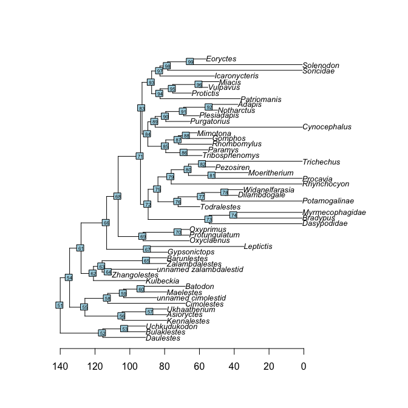

```r
## Loading and plotting the phylogeny
data(BeckLee_tree)
plot(BeckLee_tree, cex = 0.8)
axisPhylo(root = 140)
nodelabels(cex = 0.5)
```

Of course you can use your own data as detailed in the previous chapter.

### Disparity through time

The `dispRity.through.time` function calculates disparity through time, a common analysis in palaeontology. This function (and the following one) uses an analysis pipeline with a lot of default parameters to make the analysis as simple as possible. Of course all the defaults can be changed if required, more on this later.

For a disparity through time analysis, you will need:

- An ordinated matrix (we covered that above)
- A phylogenetic tree: this must be a `phylo` object (from the `ape` package) and needs a `root.time` element. To give your tree a root time (i.e. an age for the root), you can simply do `my_tree$root.time <- my_age`.
- The required number of time subsamples (here `time = 3`)
- Your favourite disparity metric (here the sum of variances)

Using the Beck and Lee (2014) data described above:

```r
## Measuring disparity through time
disparity_data <- dispRity.through.time(BeckLee_mat50, BeckLee_tree,
                                        time = 3, metric = c(sum, variances))
```

This generates a `dispRity` object (see here for technical details). When displayed, these `dispRity` objects provide us with information on the operations done to the matrix:

```r
## Print the disparity_data object
disparity_data
```

```
##  ---- dispRity object ----
## 3 discrete time subsamples for 50 elements with 48 dimensions:
##     133.51104 - 89.00736, 89.00736 - 44.50368, 44.50368 - 0.
## Data was bootstrapped 100 times (method:"full").
## Disparity was calculated as: metric.
```

We asked for three subsamples (evenly spread across the age of the tree), the data was bootstrapped 100 times (default) and the metric used was the sum of variances.

We can now summarise or plot the `disparity_data` object, or perform statistical tests on it (e.g. a simple `lm`):

```r
## Summarising disparity through time
summary(disparity_data)
```

```
##             subsamples  n   obs bs.median  2.5%   25%   75% 97.5%
## 1 133.51104 - 89.00736  5 1.575     1.305 0.729 1.118 1.420 1.509
## 2  89.00736 - 44.50368 29 1.922     1.867 1.775 1.830 1.889 1.922
## 3         44.50368 - 0 16 1.990     1.871 1.716 1.831 1.914 1.942
```

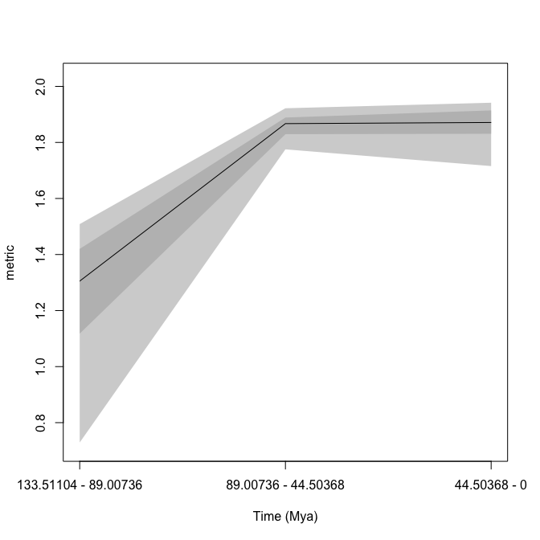

```r
## Plotting the results
plot(disparity_data, type = "continuous")
```

```r
## Testing for an difference among the time bins
disp_lm <- test.dispRity(disparity_data, test = lm, comparisons = "all")
summary(disp_lm)
```

```
##
## Call:
## test(formula = data ~ subsamples, data = data)
##
## Residuals:
##      Min       1Q   Median       3Q      Max
## -0.56623 -0.04160  0.01049  0.05507  0.31886
##
## Coefficients:
##                               Estimate Std. Error t value Pr(>|t|)
## (Intercept)                    1.25647    0.01270   98.97   <2e-16 ***
## subsamples44.50368 - 0         0.60863    0.01795   33.90   <2e-16 ***
## subsamples89.00736 - 44.50368  0.60169    0.01795   33.51   <2e-16 ***
## ---
## Signif. codes:  0 '***' 0.001 '**' 0.01 '*' 0.05 '.' 0.1 ' ' 1
##
## Residual standard error: 0.127 on 297 degrees of freedom
## Multiple R-squared:  0.8361, Adjusted R-squared:  0.835
## F-statistic: 757.5 on 2 and 297 DF,  p-value: < 2.2e-16
```

```r
## Note that ANOVA assumptions were not checked here!
```

Please refer to the specific tutorials for (much!) more information on the nuts and bolts of the package. You can also directly explore the specific function help files within R and navigate to related functions.

### Disparity among groups

The `dispRity.per.group` function is used if you are interested in looking at disparity among groups rather than through time. For example, you could ask if there is a difference in disparity between two groups?

To perform such an analysis, you will need:

- An matrix with rows as elements and columns as dimensions (always!)
- A list of group members: this list should be a list of numeric vectors or names corresponding to the row names in the matrix. For example `list("a" = c(1,2), "b" = c(3,4))` will create a group *a* containing elements 1 and 2 from the matrix and a group *b* containing elements 3 and 4. Note that elements can be present in multiple groups at once.
- Your favourite disparity metric (here the sum of variances)

Using the Beck and Lee (2014) data described above:

```r
## Creating the two groups (crown versus stem) as a list
mammal_groups <- list("crown" = c(16, 19:41, 45:50),
                      "stem" = c(1:15, 17:18, 42:44))

## Measuring disparity for each group
disparity_data <- dispRity.per.group(BeckLee_mat50, group = mammal_groups,
                                     metric = c(sum, variances))
```

We can display the disparity of both groups by simply looking at the output variable (`disparity_data`) and then summarising the `disparity_data` object and plotting it, and/or by performing a statistical test to compare disparity across the groups (here a Wilcoxon test).

```r
## Print the disparity_data object
disparity_data
```

```
##  ---- dispRity object ----
## 2 customised subsamples for 50 elements with 48 dimensions:
##     crown, stem.
## Data was bootstrapped 100 times (method:"full").
## Disparity was calculated as: metric.
```

```r
## Summarising disparity in the different groups
summary(disparity_data)
```

```
##   subsamples  n   obs bs.median  2.5%   25%   75% 97.5%
## 1      crown 30 1.995     1.936 1.866 1.914 1.947 1.971
## 2       stem 20 1.715     1.632 1.541 1.604 1.667 1.695
```

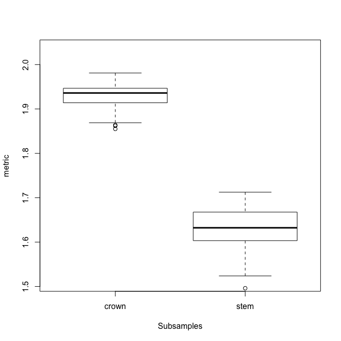

```r
## Plotting the results
plot(disparity_data)
```

```r
## Testing for a difference between the groups
test.dispRity(disparity_data, test = wilcox.test, details = TRUE)
```

```
## $`crown : stem`
## $`crown : stem`[[1]]
##
##  Wilcoxon rank sum test with continuity correction
##
## data:  dots[[1L]][[1L]] and dots[[2L]][[1L]]
## W = 10000, p-value < 2.2e-16
## alternative hypothesis: true location shift is not equal to 0
```

# Specific tutorials

The following section contains information specific to some functions. If any of your questions are not covered in these sections, please refer to the function help files in R, send me an email (guillert@tcd.ie), or raise an issue on GitHub. The several tutorials below describe specific functionalities of certain functions; please always refer to the function help files for the full function documentation!

## Time slicing

The function `time.subsamples` allows users to divide the matrix into different time subsamples or slices given a dated phylogeny that contains all the elements (i.e. taxa) from the matrix. Each subsample generated by this function will then contain all the elements present at a specific point in time or during a specific period in time.

Two types of time subsamples can be performed by using the `method` option:

- Discrete time subsamples (or time-binning) using `method = discrete`
- Continuous time subsamples (or time-slicing) using `method = continuous`

For the time-slicing method details see Guillerme and Cooper (in prep.). For both methods, the function takes the `time` argument which can be a vector of `numeric` values for:

- Defining the boundaries of the time bins (when `method = discrete`)
- Defining the time slices (when `method = continuous`)

Otherwise, the `time` argument can be set as a single `numeric` value for automatically generating a given number of equidistant time-bins/slices. Additionally, it is also possible to input a dataframe containing the first and last occurrence data (FAD/LAD) for taxa that span over a longer time than the given tips/nodes age, so taxa can appear in more than one time bin/slice.

Here is an example for `method = discrete`:

```r
## Generating three time bins containing the taxa present every 40 Ma
time.subsamples(data = BeckLee_mat50, tree = BeckLee_tree, method = "discrete",
                time = c(120, 80, 40, 0))
```

```
##  ---- dispRity object ----
## 3 discrete time subsamples for 50 elements:
##     120 - 80, 80 - 40, 40 - 0.
```

Note that we can also generate equivalent results by just telling the function that we want three time-bins as follow:

```r
## Automatically generate three equal length bins:
time.subsamples(data = BeckLee_mat50, tree = BeckLee_tree, method = "discrete",
                time = 3)
```

```
##  ---- dispRity object ----
## 3 discrete time subsamples for 50 elements:
##     133.51104 - 89.00736, 89.00736 - 44.50368, 44.50368 - 0.
```

In this example, the taxa were split inside each time-bin according to their age. However, the taxa here are considered as single points in time. It is totally possible that some taxa could have had longer longevity and that they exist in multiple time bins. In this case, it is possible to include them in more than one bin by providing a table of first and last occurrence dates (FAD/LAD). This table should have the taxa names as row names and two columns for respectively the first and last occurrence age:

```r
## Displaying the table of first and last occurrence dates for each taxa
head(BeckLee_ages)
```

```
##             FAD  LAD
## Adapis     37.2 36.8
## Asioryctes 83.6 72.1
## Leptictis  33.9 33.3
## Miacis     49.0 46.7
## Mimotona   61.6 59.2
## Notharctus 50.2 47.0
```

```r
## Generating time bins including taxa that might span between them
time.subsamples(data = BeckLee_mat50, tree = BeckLee_tree, method = "discrete",
                time = c(120, 80, 40, 0), FADLAD = BeckLee_ages)
```

```
##  ---- dispRity object ----
## 3 discrete time subsamples for 50 elements:
##     120 - 80, 80 - 40, 40 - 0.
```

When using this method, the oldest boundary of the first bin (or the first slice, see below) is automatically generated as the root age plus 1% of the tree length, as long as at least three elements/taxa are present at that point in time. The algorithm adds an extra 1% tree length until reaching the required minimum of three elements. It is also possible to include nodes in each bin by using `inc.nodes = TRUE` and providing a matrix that contains the ordinated distance among tips *and* nodes.

For the time-slicing method (`method = continuous`), the idea is fairly similar. This option, however, requires a matrix that contains the ordinated distance among taxa *and* nodes and an extra argument describing the assumed evolutionary model (via the `model` argument). This model argument is used when the time slice occurs along a branch of the tree rather than on a tip or a node, meaning that a decision must be made about what the value for the branch should be. The model can be one of the following:

- `acctran` where the data chosen along the branch is always the one of the descendant
- `deltran` where the data chosen along the branch is always the one of the ancestor
- `punctuated` where the data chosen along the branch is randomly chosen between the descendant or the ancestor
- `gradual` where the data chosen along the branch is either the descendant or the ancestor depending on branch length

```r
## Generating four time slices every 40 million years under a model of gradual evolution
time.subsamples(data = BeckLee_mat99, tree = BeckLee_tree,
    method = "continuous", model = "gradual", time = c(120, 80, 40, 0),
    FADLAD = BeckLee_ages)
```

```
##  ---- dispRity object ----
## 4 continuous (gradual) time subsamples for 99 elements:
##     120, 80, 40, 0.
```

```r
## Generating four time slices automatically
time.subsamples(data = BeckLee_mat99, tree = BeckLee_tree,
    method = "continuous", model = "gradual", time = 4, FADLAD = BeckLee_ages)
```

```
##  ---- dispRity object ----
## 4 continuous (gradual) time subsamples for 99 elements:
##     133.51104, 89.00736, 44.50368, 0.
```

## Customised subsamples

Another way of separating elements into different categories is to use customised subsamples as briefly explained above. This function simply takes the list of elements to put in each group (whether they are the actual element names or their position in the matrix).

```r
## Creating the two groups as a list
mammal_groups <- list("crown" = c(16, 19:41, 45:50),
                      "stem" = c(1:15, 17:18, 42:44))

## Separating the dataset into two different groups
custom.subsamples(BeckLee_mat50, group = mammal_groups)
```

```
##  ---- dispRity object ----
## 2 customised subsamples for 50 elements:
##     crown, stem.
```

Elements can easily be assigned to different groups if necessary!

```r
## Creating the three groups as a list
mammal_groups <- list("crown" = c(16, 19:41, 45:50),
                      "stem" = c(1:15, 17:18, 42:44).
                      "all" = c(1:50))
```

## Bootstraps and rarefactions

One important step in analysing ordinated matrices is to pseudo-replicate the data to see how robust the results are, and how sensitive they are to outliers in the dataset. This can be achieved using the function `boot.matrix` to bootstrap and/or rarefy the data. The default options will bootstrap the matrix 100 times without rarefaction using the “full” bootstrap method (see below):

```r
## Default bootstrapping
boot.matrix(data = BeckLee_mat50)
```

```
##  ---- dispRity object ----
## 50 elements with 48 dimensions.
## Data was bootstrapped 100 times (method:"full").
```

The number of bootstrap replicates can be defined using the `bootstraps` option. The method can be modified by controlling which bootstrap algorithm to use through the `boot.type` argument. Currently two algorithms are implemented:

- `full` where the bootstrapping is entirely stochastic (*n* elements are replaced by any *m* elements drawn from the data)
- `single` where only one random element is replaced by one other random element for each pseudo-replicate

```r
## Bootstrapping with the single bootstrap method
boot.matrix(BeckLee_mat50, boot.type = "single")
```

```
##  ---- dispRity object ----
## 50 elements with 48 dimensions.
## Data was bootstrapped 100 times (method:"single").
```

This function also allows users to rarefy the data using the `rarefaction` argument. Rarefaction allows users to limit the number of elements to be drawn at each bootstrap replication. This is useful if, for example, one is interested in looking at the effect of reducing the number of elements on the results of an analysis.

This can be achieved by using the `rarefaction` option that draws only *n-x* at each bootstrap replicate (where *x* is the number of elements not sampled). The default argument is `FALSE` but it can be set to `TRUE` to fully rarefy the data (i.e. remove *x* elements for the number of pseudo-replicates, where *x* varies from the maximum number of elements present in each subsample to a minimum of three elements). It can also be set to one or more `numeric` values to only rarefy to the corresponding number of elements.

```r
## Bootstrapping with the full rarefaction
boot.matrix(BeckLee_mat50, bootstraps = 20, rarefaction = TRUE)
```

```
##  ---- dispRity object ----
## 50 elements with 48 dimensions.
## Data was bootstrapped 20 times (method:"full") and fully rarefied.
```

```r
## Or with a set number of rarefaction levels
boot.matrix(BeckLee_mat50, bootstraps = 20, rarefaction = c(6:8, 3))
```

```
##  ---- dispRity object ----
## 50 elements with 48 dimensions.
## Data was bootstrapped 20 times (method:"full") and rarefied to 6, 7, 8, 3 elements.
```

One additional important argument is `dimensions` that specifies how many dimensions from the matrix should be used for further analysis. When missing, all dimensions from the ordinated matrix are used.

```r
## Using the first 50% of the dimensions
boot.matrix(BeckLee_mat50, dimensions = 0.5)
```

```
##  ---- dispRity object ----
## 50 elements with 24 dimensions.
## Data was bootstrapped 100 times (method:"full").
```

```r
## Using the first 10 dimensions
boot.matrix(BeckLee_mat50, dimensions = 10)
```

```
##  ---- dispRity object ----
## 50 elements with 10 dimensions.
## Data was bootstrapped 100 times (method:"full").
```

Of course, one could directly supply the subsamples generated above (using `time.subsamples` or `custom.subsamples`) to this function.

```r
## Creating subsamples of crown and stem mammals
crown_stem <- custom.subsamples(BeckLee_mat50,
                                group = list("crown" = c(16, 19:41, 45:50),
                                             "stem" = c(1:15, 17:18, 42:44)))
## Bootstrapping and rarefying these groups
boot.matrix(crown_stem, bootstraps = 200, rarefaction = TRUE)
```

```
##  ---- dispRity object ----
## 2 customised subsamples for 50 elements with 48 dimensions:
##     crown, stem.
## Data was bootstrapped 200 times (method:"full") and fully rarefied.
```

```r
## Creating time slice subsamples
time_slices <- time.subsamples(data = BeckLee_mat99, tree = BeckLee_tree,
                               method = "continuous", model = "gradual",
                               time = c(120, 80, 40, 0),
                               FADLAD = BeckLee_ages)

## Bootstrapping the time slice subsamples
boot.matrix(time_slices, bootstraps = 100)
```

```
##  ---- dispRity object ----
## 4 continuous (gradual) time subsamples for 99 elements with 97 dimensions:
##     120, 80, 40, 0.
## Data was bootstrapped 100 times (method:"full").
```

## Disparity metrics

There are many ways of measuring disparity! In brief, disparity is a summary metric that will represent an aspect of an ordinated space (e.g. a MDS, PCA, PCO, PCoA). For example, one can look at ellipsoid hyper-volume of the ordinated space Donohue et al. (2013), the sum and the product of the ranges and variances Wills, Briggs, and Fortey (1994–4AD) or the median position of the elements relative to their centroid Wills, Briggs, and Fortey (1994–4AD). Of course, there are many more examples of metrics one can use for describing some aspect of the ordinated space, with some performing better than other ones at particular descriptive tasks, and some being more generalist.

Because of this great diversity of metrics, the package `dispRity` does not have one way to measure disparity but rather proposes to facilitate users in defining their own disparity metric that will best suit their particular analysis. In fact, the core function of the package, `dispRity`, allows the user to define any metric with the `metric` argument. However the `metric` argument has to follow certain rules:

1. It must be composed from one to three `function` objects;
2. The function(s) must take as a first argument a `matrix` or a `vector`;
3. The function(s) must be of one of the three dimension-levels described below;
4. At least one of the functions must be of dimension-level 1 or 2 (see below).

### The function dimension-levels

The metric function dimension-levels determine the “dimensionality of decomposition” of the input matrix. In other words, each dimension-level designates the dimensions of the output, i.e. either three (a `matrix`); two (a `vector`); or one (a single `numeric` value) dimension.

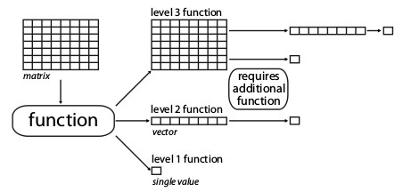

Illustration of the different dimension-levels of functions with an input `matrix`

#### Dimension-level 1 functions

A dimension-level 1 function will decompose a `matrix` or a `vector` into a single value:

```r
## Creating a dummy matrix
dummy_matrix <- matrix(rnorm(12), 4, 3)

## Example of dimension-level 1 functions
mean(dummy_matrix)
```

```
## [1] -0.3227241
```

```r
median(dummy_matrix)
```

```
## [1] -0.2690165
```

Any summary metric such as mean or median are good examples of dimension-level 1 functions as they reduce the matrix to a single dimension (i.e. one value).

#### Dimension-level 2 functions

A dimension-level 2 function will decompose a `matrix` into a `vector`.

```r
## Defining the function as the product of rows
prod.rows <- function(matrix) apply(matrix, 1, prod)

## A dimension-level 2 metric
prod.rows(dummy_matrix)
```

```
## [1] -1.2630799  0.2148864 -0.1797556 -0.2421790
```

Several dimension-level 2 functions are implemented in `dispRity` (see `?dispRity.metric`) such as the `variances` or `ranges` functions that calculate the variance or the range of each dimension of the ordinated matrix respectively.

#### Dimension-level 3 functions

Finally a dimension-level 3 function will transform the matrix into another matrix. Note that the dimension of the output matrix doesn’t need to match the the input matrix:

```r
## A dimension-level 3 metric
var(dummy_matrix)
```

```
##          [,1]      [,2]      [,3]
## [1,] 1.916420 1.9501955 0.2907060
## [2,] 1.950196 3.2948635 0.3958234
## [3,] 0.290706 0.3958234 0.6704976
```

```r
## A dimension-level 3 metric with a forced matrix output
as.matrix(dist(dummy_matrix))
```

```
##          1        2        3        4
## 1 0.000000 5.140790 4.005068 3.120827
## 2 5.140790 0.000000 2.179318 2.982267
## 3 4.005068 2.179318 0.000000 2.174896
## 4 3.120827 2.982267 2.174896 0.000000
```

### `make.metric`

Of course, functions can be more complex and involve multiple operations such as the `centroids` function (see `?dispRity.metric`) that calculates the Euclidean distance between each element and the centroid of the ordinated space. The `make.metric` function implemented in `dispRity` is designed to help test and find the dimension-level of the functions. This function tests:

1. If your function can deal with a `matrix` or a `vector` as an input;
2. Your function’s dimension-level according to its output (dimension-level 1, 2 or 3, see above);
3. Whether the function can be implemented in the `dispRity` function (the function is fed into a `lapply` loop).

For example, let’s see if the functions described above are the right dimension-levels:

```r
## Which dimension-level is the mean function? And can it be used in dispRity?
make.metric(mean)
```

```
## mean outputs a single value.
## mean is detected as being a dimension-level 1 function.
```

```r
## Which dimension-level is the prod.rows function? And can it be used in dispRity?
make.metric(prod.rows)
```

```
## prod.rows outputs a matrix object.
## prod.rows is detected as being a dimension-level 2 function.
```

```r
## Which dimension-level is the var function? And can it be used in dispRity?
make.metric(var)
```

```
## var outputs a matrix object.
## var is detected as being a dimension-level 3 function.
## Additional dimension-level 2 and/or 1 function(s) will be needed.
```

A non verbose version of the function is also available. This can be done using the option `silent = TRUE` and will simply output the dimension-level of the metric.

```r
## Testing whether mean is dimension-level 1
if(make.metric(mean, silent = TRUE) != "level1") {
    message("The metric is not dimension-level 1.")
}
## Testing whether var is dimension-level 1
if(make.metric(var, silent = TRUE) != "level1") {
    message("The metric is not dimension-level 1.")
}
```

```
## The metric is not dimension-level 1.
```

### Metrics in the `dispRity` function

Using this metric structure, we can easily use any disparity metric in the `dispRity` function as follows:

```r
## Measuring disparity as the standard deviation of all the values of the
## ordinated matrix (dimension-level 1 function).
summary(dispRity(BeckLee_mat50, metric = sd))
```

```
##   subsamples  n   obs
## 1          1 50 0.201
```

```r
## Measuring disparity as the standard deviation of the variance of each axis of
## the ordinated matrix (dimension-level 1 and 2 functions).
summary(dispRity(BeckLee_mat50, metric = c(sd, variances)))
```

```
##   subsamples  n   obs
## 1          1 50 0.028
```

```r
## Measuring disparity as the standard deviation of the variance of each axis of
## the variance covariance matrix (dimension-level 1, 2 and 3 functions).
summary(dispRity(BeckLee_mat50, metric = c(sd, variances, var)), round = 10)
```

```
##   subsamples  n          obs
## 1          1 50 0.0001025857
```

Note that the order of each function in the metric argument does not matter, the `dispRity` function will automatically detect the function dimension-levels (using `make.metric`) and apply them to the data in decreasing order (dimension-level 3 > 2 > 1).

```r
## Disparity as the standard deviation of the variance of each axis of the
## variance covariance matrix:
disparity1 <- summary(dispRity(BeckLee_mat50, metric = c(sd, variances, var)),
                      round = 10)

## Same as above but using a different function order for the metric argument
disparity2 <- summary(dispRity(BeckLee_mat50, metric = c(variances, sd, var)),
                      round = 10)

## Both ways output the same disparity values:
disparity1 == disparity2
```

```
##      subsamples    n  obs
## [1,]       TRUE TRUE TRUE
```

In these examples, we considered disparity to be a single value. For example, in the previous example, we defined disparity as the standard deviation of the variances of each column of the variance/covariance matrix (`metric = c(variances, sd, var)`). It is, however, possible to calculate disparity as a distribution.

### Metrics implemented in `dispRity`

Several disparity metrics are implemented in the `dispRity` package. The detailed list can be found in `?dispRity.metric` along with some description of each metric.

| Level | Name | Description | Source |
| --- | --- | --- | --- |
| 3 | `ellipse.volume`<sup>1</sup> | The volume of the ellipsoid of the space | (Donohue et al. 2013) |
| 3 | `convhull.surface` | The surface of the convex hull formed by all the elements | [`geometry`](https://cran.r-project.org/web/packages/geometry/index.html)`::convhulln` |
| 3 | `convhull.volume` | The volume of the convex hull formed by all the elements | [`geometry`](https://cran.r-project.org/web/packages/geometry/index.html)`::convhulln` |
| 3 | `hypervolume` | The volume of the ordinated space | [`hypervolume`](https://cran.r-project.org/web/packages/hypervolume/index.html)`::hypervolume` |
| 3 | `diagonal` | The longest distance in the ordinated space (like the diagonal in two dimensions) | `dispRity` |
| 2 | `ranges` | The range of each dimension | `dispRity` |
| 2 | `variances` | The variance of each dimension | `dispRity` |
| 2 | `centroids`<sup>2</sup> | The distance between each element and the centroid of the ordinated space | `dispRity` |
| 1 | `mode.val` | The modal value | `dispRity` |

1: This function uses an estimation of the eigenvalue that only works for MDS or PCoA ordinations (not PCA).

2: Note that by default, the centroid is the centroid of the elements. It can, however, be fixed to a different value by using the `centroid` argument `centroids(space, centroid = rep(0, ncol(space)))`, for example the origin of the ordinated space.

### Equations and implementations

Some of the functions described below are implemented in the `dispRity` package and do not require any other packages to calculate ([see implementation here](https://github.com/TGuillerme/dispRity/blob/master/R/dispRity.metric.R)).

\begin{equation} ellipse.volume = \frac{\pi^{k/2}}{\Gamma(\frac{k}{2}+1)}\displaystyle\prod_{i=1}^{k} (\lambda_{i}^{0.5}) \end{equation}

Where *k* is the number of dimensions, and $\lambda_i$ is the eigenvalue of each dimension.

\begin{equation} diagonal = \sqrt{\sum_{i=1}^{k}|max(k_i) - min(k_i)|} \end{equation}

Where *k* is the number of dimensions.

\begin{equation} ranges = |max(k_i) - min(k_i)| \end{equation}

Where *k* is the number of dimensions.

\begin{equation} variances = \sigma^{2}{k_i} \end{equation}

Where *k* is the number of dimensions, and $\sigma^{2}$ is their variance.

\begin{equation} centroids = \sqrt{\sum_{i=1}^{n}{({k}_{n}-Centroid_{k})^2}} \end{equation}

Where *n* is each element in the ordinated space, *k* is the number of dimensions, and $Centroid_{k}$ is their mean (or can be set to another value).

### Using the different disparity metrics

Here is a brief demonstration of the main metrics implemented in `dispRity`. First, we will create a dummy/simulated ordinated space using the `space.maker` utility function (more about that here:

```r
## Creating a 10*5 normal space
set.seed(1)
dummy_space <- space.maker(10, 5, rnorm)
```

We will use this simulated space to demonstrate the different metrics.

#### Volumes and surface metrics

The functions `ellipse.volume`, `convhull.surface`, `convhull.volume` and `hyper.volume` all measure the surface or the volume of the ordinated space occupied:

```r
## Calculating the ellipsoid volume
summary(dispRity(dummy_space, metric = ellipse.volume))
```

```
##   subsamples  n   obs
## 1          1 10 257.8
```

> Because there is only one subsample (i.e. one matrix) in the dispRity object, this operation is the equivalent of `ellipse.volume(dummy_space)` (with rounding).

```r
## Calculating the convex hull surface
summary(dispRity(dummy_space, metric = convhull.surface))
```

```
##   subsamples  n   obs
## 1          1 10 11.91
```

```r
## Calculating the convex hull volume
summary(dispRity(dummy_space, metric = convhull.volume))
```

```
##   subsamples  n   obs
## 1          1 10 1.031
```

The convex hull functions make a (good) estimation of the multidimensional properties of the ordinated space. For the full and correct calculation of the volume of the ordinated space, it is possible to use the `hyper.volume` function that has more options but takes longer to calculate.

```r
## Calculating the true multidimensional volume
summary(dispRity(dummy_space, metric = hyper.volume))
```

```
##   subsamples  n   obs
## 1          1 10 408.2
```

> Cautionary note: measuring volumes in a high number of dimensions can be strongly affected by the [curse of dimensionality](https://en.wikipedia.org/wiki/Curse_of_dimensionality) that often results in near 0 disparity values.

#### Ranges, variances and diagonal

The functions `ranges`, `variances` and `diagonal` all measure properties of the ordinated space based on its dimensional properties (they are also less affected by the “curse of dimensionality”):

`ranges` and `variances` both work on the same principle and measure the range/variance of each dimension:

```r
## Calculating the ranges of each dimension in the ordinated space
ranges(dummy_space)
```

```
## [1] 2.430909 3.726481 2.908329 2.735739 1.588603
```

```r
## Calculating disparity as the distribution of these ranges
summary(dispRity(dummy_space, metric = ranges))
```

```
##   subsamples  n obs.median  2.5%   25%   75% 97.5%
## 1          1 10      2.736 1.673 2.431 2.908 3.645
```

```r
## Calculating disparity as the sum and the product of these ranges
summary(dispRity(dummy_space, metric = c(sum, ranges)))
```

```
##   subsamples  n   obs
## 1          1 10 13.39
```

```r
summary(dispRity(dummy_space, metric = c(prod, ranges)))
```

```
##   subsamples  n   obs
## 1          1 10 114.5
```

```r
## Calculating the variances of each dimension in the ordinated space
variances(dummy_space)
```

```
## [1] 0.6093144 1.1438620 0.9131859 0.6537768 0.3549372
```

```r
## Calculating disparity as the distribution of these variances
summary(dispRity(dummy_space, metric = variances))
```

```
##   subsamples  n obs.median 2.5%   25%   75% 97.5%
## 1          1 10      0.654 0.38 0.609 0.913 1.121
```

```r
## Calculating disparity as the sum and the product of these variances
summary(dispRity(dummy_space, metric = c(sum, variances)))
```

```
##   subsamples  n   obs
## 1          1 10 3.675
```

```r
summary(dispRity(dummy_space, metric = c(prod, variances)))
```

```
##   subsamples  n   obs
## 1          1 10 0.148
```

The `diagonal` function measures the multidimensional diagonal of the whole space (i.e. in our case the longest Euclidean distance in our five dimensional space):

```r
## Calculating the ordinated space's diagonal
summary(dispRity(dummy_space, metric = diagonal))
```

```
##   subsamples  n   obs
## 1          1 10 3.659
```

> This metric is only a Euclidean diagonal (mathematically valid) if the dimensions within the space are all orthogonal!

#### Centroids metric

The `centroids` metric allows users to measure the position of the different elements compared to a fixed point in the ordinated space. By default, this function measures the distance between each element and their centroid (centre point):

```r
## The distribution of the distances between each element and their centroid
summary(dispRity(dummy_space, metric = centroids))
```

```
##   subsamples  n obs.median  2.5%   25%   75% 97.5%
## 1          1 10      1.435 0.788 1.267 1.993 3.167
```

```r
## Disparity as the median value of these distances
summary(dispRity(dummy_space, metric = c(median, centroids)))
```

```
##   subsamples  n   obs
## 1          1 10 1.435
```

It is however possible to fix the coordinates of the centroid to a specific point in the ordinated space, as long as it has the correct number of dimensions:

```r
## The distance between each element and the origin of the ordinated space
summary(dispRity(dummy_space, metric = centroids, centroid = c(0,0,0,0,0)))
```

```
##   subsamples  n obs.median  2.5% 25%   75% 97.5%
## 1          1 10      1.487 0.785 1.2 2.044 3.176
```

```r
## Disparity as the distance between each element and a specific point in space
summary(dispRity(dummy_space, metric = centroids, centroid = c(0,1,2,3,4)))
```

```
##   subsamples  n obs.median  2.5%   25%   75% 97.5%
## 1          1 10      5.489 4.293 5.032 6.155 6.957
```

## Summarising dispRity data (plots)

Because of its architecture, printing `dispRity` objects only summarises their content but does not print the disparity value measured or associated analysis (more about this here). To actually see what is in a dispRity object, one can either use the `summary` function for visualising the data in a table or `plot` to have a graphical representation of the results.

### Summarising `dispRity` data

This function is an S3 function (`summary.dispRity`) allowing users to summarise the content of `dispRity` objects that contain disparity calculations.

```r
## Example data from previous sections
crown_stem <- custom.subsamples(BeckLee_mat50,
                                group = list("crown" = c(16, 19:41, 45:50),
                                             "stem" = c(1:15, 17:18, 42:44)))
## Bootstrapping and rarefying these groups
boot_crown_stem <- boot.matrix(crown_stem, bootstraps = 100, rarefaction = TRUE)
## Calculate disparity
disparity_crown_stem <- dispRity(boot_crown_stem, metric = c(sum, variances))

## Creating time slice subsamples
time_slices <- time.subsamples(data = BeckLee_mat99, tree = BeckLee_tree,
    method = "continuous", model = "gradual", time = c(120, 80, 40, 0),
    FADLAD = BeckLee_ages)
## Bootstrapping the time slice subsamples
boot_time_slices <- boot.matrix(time_slices, bootstraps = 100)
## Calculate disparity
disparity_time_slices <- dispRity(boot_time_slices, metric = c(sum, variances))

## Creating time bin subsamples
time_bins <- time.subsamples(data = BeckLee_mat99, tree = BeckLee_tree,
    method = "discrete", time = c(120, 80, 40, 0), FADLAD = BeckLee_ages,
    inc.nodes = TRUE)
## Bootstrapping the time bin subsamples
boot_time_bins <- boot.matrix(time_bins, bootstraps = 100)
## Calculate disparity
disparity_time_bins <- dispRity(boot_time_bins, metric = c(sum, variances))
```

These objects are easy to summarise as follows:

```r
## Default summary
summary(disparity_time_slices)
```

```
##   subsamples  n   obs bs.median  2.5%   25%   75% 97.5%
## 1        120  5 2.823     2.295 1.292 2.039 2.598 2.829
## 2         80 19 3.233     3.079 2.834 2.996 3.138 3.278
## 3         40 15 3.421     3.211 2.909 3.103 3.309 3.518
## 4          0 10 4.055     3.684 3.247 3.557 3.783 3.940
```

Information about the number of elements in each subsample and the observed (i.e. non-bootstrapped) disparity are also calculated. This is specifically handy when rarefying the data for example:

```r
head(summary(disparity_crown_stem))
```

```
##   subsamples  n   obs bs.median  2.5%   25%   75% 97.5%
## 1      crown 30 1.995     1.926 1.863 1.912 1.948 1.965
## 2      crown 29    NA     1.931 1.878 1.909 1.944 1.967
## 3      crown 28    NA     1.931 1.882 1.908 1.948 1.978
## 4      crown 27    NA     1.930 1.859 1.908 1.946 1.966
## 5      crown 26    NA     1.928 1.867 1.907 1.948 1.978
## 6      crown 25    NA     1.934 1.853 1.904 1.948 1.974
```

The summary functions can also take various options such as:

- `quantile` values for the confidence interval levels (by default, the 50 and 95 quantiles are calculated)
- `cent.tend` for the central tendency to use for summarising the results (default is `median`)
- rounding`option corresponding to the number of decimal places to print (default is`2`)
- `recall` option for printing the call of the `dispRity` object as well (default is `FALSE`)

These options can easily be changed from the defaults as follows:

```r
## Same as above but using the 88th quantile and the standard deviation as the summary
summary(disparity_time_slices, quantile = 88, cent.tend = sd)
```

```
##   subsamples  n   obs bs.sd    6%   94%
## 1        120  5 2.823 0.398 1.658 2.705
## 2         80 19 3.233 0.116 2.896 3.243
## 3         40 15 3.421 0.161 2.967 3.485
## 4          0 10 4.055 0.184 3.342 3.907
```

```r
## Printing the details of the object and rounding the values to the 5th decimal place
summary(disparity_time_slices, recall = TRUE, rounding = 5)
```

```
##  ---- dispRity object ----
## 4 continuous (gradual) time subsamples for 99 elements with 97 dimensions:
##     120, 80, 40, 0.
## Data was bootstrapped 100 times (method:"full").
## Disparity was calculated as: c(sum, variances).
```

```
##   subsamples  n     obs bs.median    2.5%     25%     75%   97.5%
## 1        120  5 2.82292   2.29498 1.29247 2.03886 2.59781 2.82881
## 2         80 19 3.23312   3.07949 2.83426 2.99627 3.13758 3.27800
## 3         40 15 3.42091   3.21071 2.90858 3.10280 3.30911 3.51829
## 4          0 10 4.05457   3.68433 3.24678 3.55676 3.78275 3.93967
```

Note that the summary table is a `data.frame`, hence it is as easy to modify as any dataframe using `dplyr`. You can also export it in `csv` format using `write.csv` or `write_csv` or even directly export into `LaTeX` format using the following;

```r
## Loading the xtable package
require(xtable)
## Converting the table in LaTeX
xtable(summary(disparity_time_slices))
```

### Plotting `dispRity` data

An alternative (and more fun!) way to display the calculated disparity is to plot the results using the S3 method `plot.dispRity`. This function takes the same options as `summary.dispRity` along with various graphical options described in the function help files (see `?plot.dispRity`).

The plots can be of four different types:

- `continuous` for displaying continuous disparity curves
- `box`, `lines`, and `polygons` to display discrete disparity results in respectively a boxplot, confidence interval lines, and confidence interval polygons.

> This argument can be left empty. In this case, the algorithm will automatically detect the type of subsamples from the `dispRity` object and plot accordingly.

It is also possible to display the number of elements in each subsample (as a horizontal dotted line) using the option `elements = TRUE`. Additionally, when the data is rarefied, one can indicate which level of rarefaction to display (i.e. only display the results for a certain number of elements) by using the `rarefaction` argument.

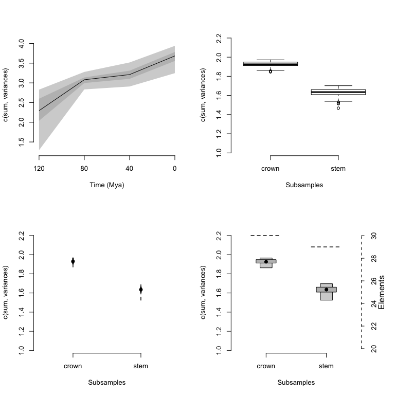

```r
## Graphical parameters
op <- par(mfrow = c(2, 2), bty = "n")

## Plotting continuous disparity results
plot(disparity_time_slices, type = "continuous")

## Plotting discrete disparity results
plot(disparity_crown_stem, type = "box")

## As above but using lines for the rarefaction level of 20 elements only
plot(disparity_crown_stem, type = "line", rarefaction = 20)

## As above but using polygons while also displaying the number of elements
plot(disparity_crown_stem, type = "polygon", elements = TRUE)
```

```r
## Resetting graphical parameters
par(op)
```

Since `plot.dispRity` uses the arguments from the generic `plot` method, it is of course possible to change pretty much everything using the regular plot arguments:

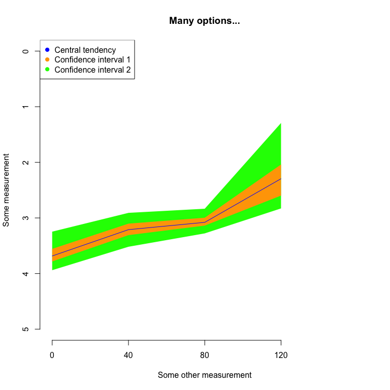

```r
## Graphical options
op <- par(bty = "n")

## Plotting the results with some classic options from plot
plot(disparity_time_slices, col = c("blue", "orange", "green"),
    ylab = c("Some measurement"), xlab = "Some other measurement",
    main = "Many options...", ylim = c(5, 0), xlim = c(4, 0))

## Adding a legend
legend("topleft", legend = c("Central tendency",
                             "Confidence interval 1",
                            "Confidence interval 2"),
      col = c("blue", "orange", "green"), pch = 19)
```

```r
## Resetting graphical parameters
par(op)
```

In addition to the classic `plot` arguments, the function can also take arguments that are specific to `plot.dispRity` like adding the number of elements or rarefaction level (as described above), and also changing the values of the quantiles to plot as well as the central tendency.

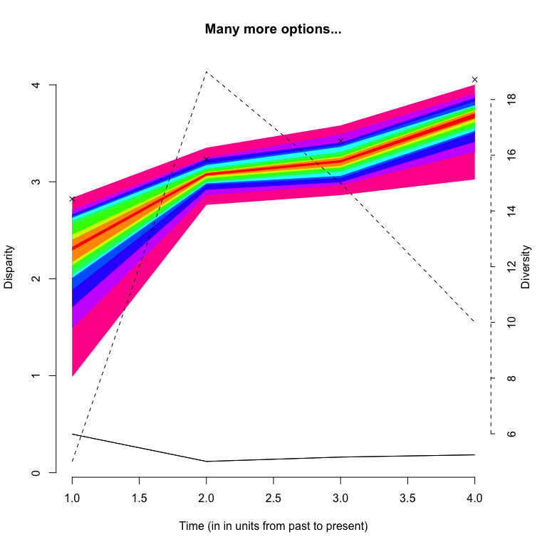

```r
## Graphical options
op <- par(bty = "n")

## Plotting the results with some plot.dispRity arguments
plot(disparity_time_slices, quantile = c(seq(from = 10, to = 100, by = 10)),
    cent.tend = sd, type = "c", elements = TRUE, col = c("black", rainbow(10)),
    ylab = c("Disparity", "Diversity"), time.subsamples = FALSE,
    xlab = "Time (in in units from past to present)", observed = TRUE,
    main = "Many more options...")
```

```r
## Resetting graphical parameters
par(op)
```

> Note that the argument `observed = TRUE` allows to plot the disparity values calculated from the non-bootstrapped data as crosses on the plot.

For comparing results, it is also possible to add a plot to the existent plot by using `add = TRUE`:

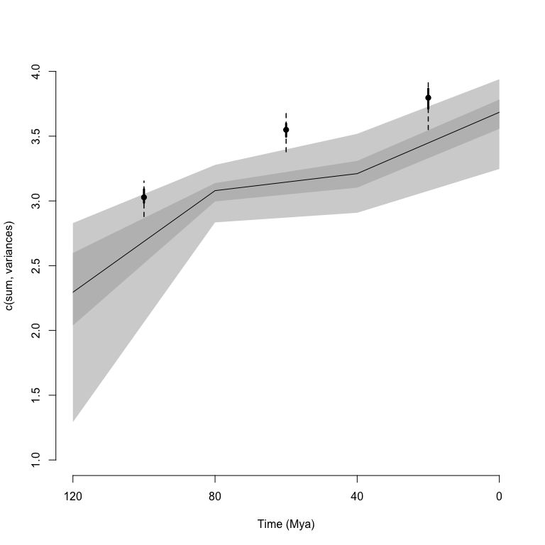

```r
## Graphical options
op <- par(bty = "n")

## Plotting the continuous disparity with a fixed y axis
plot(disparity_time_slices, ylim = c(1, 4))
## Adding the discrete data
plot(disparity_time_bins, type = "line", ylim = c(1, 4), xlab = "", ylab = "",
    add = TRUE)
```

```r
## Resetting graphical parameters
par(op)
```

Finally, if your data has been fully rarefied, it is also possible to easily look at rarefaction curves by using the `rarefaction = TRUE` argument:

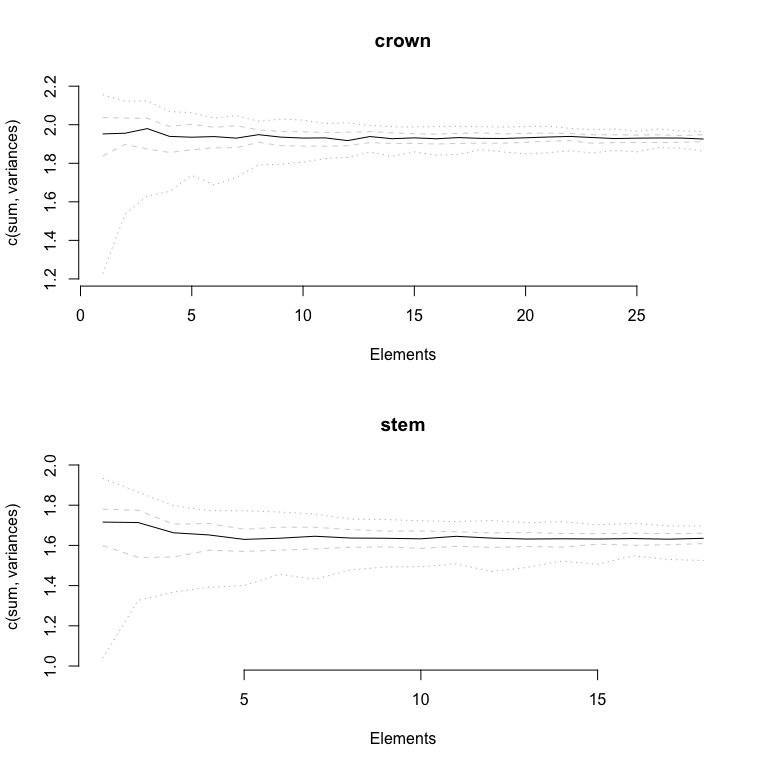

```r
## Graphical options
op <- par(bty = "n")

## Plotting the rarefaction curves
plot(disparity_crown_stem, rarefaction = TRUE)
```

```r
## Resetting graphical parameters
par(op)
```

## Testing disparity hypotheses

The `dispRity` package allows users to apply statistical tests to the calculated disparity to test various hypotheses. The function `test.dispRity` works in a similar way to the `dispRity` function: it takes a `dispRity` object, a `test` and a `comparisons` argument.

The `comparisons` argument indicates the way the test should be applied to the data:

- `pairwise` (default): to compare each subsample in a pairwise manner
- `referential`: to compare each subsample to the first subsample
- `sequential`: to compare each subsample to the following subsample
- `all`: to compare all the subsamples together (like in analysis of variance)

It is also possible to input a list of pairs of `numeric` values or `characters` matching the subsample names to create personalised tests. Some other tests implemented in `dispRity` such as the `dispRity::null.test` have a specific way they are applied to the data and therefore ignore the `comparisons` argument.

The `test` argument can be any statistical or non-statistical test to apply to the disparity object. It can be a common statistical test function (e.g. `stats::t.test`), a function implemented in `dispRity` (e.g. see `?null.test`) or any function defined by the user.

This function also allows users to correct for Type I error inflation (false positives) when using multiple comparisons via the `correction` argument. This argument can be empty (no correction applied) or can contain one of the corrections from the `stats::p.adjust` function (see `?p.adjust`).

Note that the `test.dispRity` algorithm deals with some classical test outputs (`h.test`, `lm` and `numeric` vector) and summarises the test output. It is, however, possible to get the full detailed output by using the options `details = TRUE`.

```r
## T-test to test for a difference in disparity between crown and stem mammals
test.dispRity(disparity_crown_stem, test = t.test)
```

```
## [[1]]
##              statistic
## crown : stem  55.60162
##
## [[2]]
##              parameter
## crown : stem  164.6932
##
## [[3]]
##                    p.value
## crown : stem 1.201122e-108
```

```r
## Performing the same test but with the detailed t.test output
test.dispRity(disparity_crown_stem, test = t.test, details = TRUE)
```

```
## $`crown : stem`
## $`crown : stem`[[1]]
##
##  Welch Two Sample t-test
##
## data:  dots[[1L]][[1L]] and dots[[2L]][[1L]]
## t = 55.602, df = 164.69, p-value < 2.2e-16
## alternative hypothesis: true difference in means is not equal to 0
## 95 percent confidence interval:
##  0.2849688 0.3059530
## sample estimates:
## mean of x mean of y
##  1.926163  1.630702
```

```r
## Wilcoxon test applied to time sliced disparity with sequential comparisons, with Bonferroni correction
test.dispRity(disparity_time_slices, test = wilcox.test,
              comparisons = "sequential", correction = "bonferroni")
```

```
## [[1]]
##          statistic
## 120 : 80        13
## 80 : 40       2497
## 40 : 0         426
##
## [[2]]
##               p.value
## 120 : 80 1.130227e-33
## 80 : 40  2.904335e-09
## 40 : 0   1.624453e-28
```

```r
## Measuring the overlap between distributions in the time bins (using the
## implemented Bhattacharyya Coefficient function - see ?bhatt.coeff)
test.dispRity(disparity_time_bins, test = bhatt.coeff)
```

```
##                    bhatt.coeff
## 120 - 80 : 80 - 40   0.0000000
## 120 - 80 : 40 - 0    0.0000000
## 80 - 40 : 40 - 0     0.4195376
```

It is also possible to apply some more *complex* tests that have their own output classes (like `stats::lm`).

The results can then be analysed as usual using the associated `summary` S3 method:

```r
## Performing and linear model applied to the same data
(slice_lm <- test.dispRity(disparity_time_slices, test = lm,
                            comparisons = "all"))
```

```
##
## Call:
## test(formula = data ~ subsamples, data = data)
##
## Coefficients:
##   (Intercept)  subsamples120   subsamples40   subsamples80
##        3.6571        -1.4046        -0.4481        -0.5863
```

```r
## The output is a regular `lm` output
class(slice_lm)
```

```
## [1] "lm"
```

```r
## This output can be summarised using summary
summary(slice_lm)
```

```
##
## Call:
## test(formula = data ~ subsamples, data = data)
##
## Residuals:
##      Min       1Q   Median       3Q      Max
## -1.26522 -0.10976  0.01515  0.13109  0.58161
##
## Coefficients:
##               Estimate Std. Error t value Pr(>|t|)
## (Intercept)    3.65712    0.02406  151.99   <2e-16 ***
## subsamples120 -1.40459    0.03403  -41.28   <2e-16 ***
## subsamples40  -0.44812    0.03403  -13.17   <2e-16 ***
## subsamples80  -0.58634    0.03403  -17.23   <2e-16 ***
## ---
## Signif. codes:  0 '***' 0.001 '**' 0.01 '*' 0.05 '.' 0.1 ' ' 1
##
## Residual standard error: 0.2406 on 396 degrees of freedom
## Multiple R-squared:  0.818,  Adjusted R-squared:  0.8166
## F-statistic: 593.1 on 3 and 396 DF,  p-value: < 2.2e-16
```

Of course, due to the modular design of the package, tests can always be made by the user (the same way disparity metrics can be user made). The only condition is that the test can be applied to at least two distributions. In practice, the `test.dispRity` function will pass the calculated disparity data (distributions) to the provided function in either pairs of distributions (if the `comparisons` argument is set to `pairwise`, `referential` or `sequential`) or a table containing all the distributions (`comparisons = all`; this should be in the same format as data passed to `lm` for example).

## Disparity as a distribution

Disparity is often regarded as a summary value of the position of the all elements in the ordinated space. For example, the sum of variances, the product of ranges or the median distance between the elements and their centroid will summarise disparity as a single value. This value can be pseudo-replicated (bootstrapped) to obtain a distribution of the summary metric with estimated error. However, another way to perform disparity analysis is to use the *whole distribution* rather than just a summary metric (e.g. the variances or the ranges).

This is possible in the `dispRity` package by calculating disparity as a dimension-level 2 metric only! Let’s have a look using our previous example of bootstrapped time slices but by measuring the distances between each taxon and their centroid as disparity.

```r
## Measuring disparity as a whole distribution
disparity_centroids <- dispRity(boot_time_slices, metric = centroids)
```

The resulting disparity object is of dimension-level 2, so it can easily be transformed into a dimension-level 1 object by, for example, measuring the median distance of all these distributions:

```r
## Measuring median disparity in each time slice
disparity_centroids_median <- dispRity(disparity_centroids, metric = median)
```

And we can now compare the differences between these methods:

```r
## Summarising both disparity measurements:
## The distributions:
summary(disparity_centroids)
```

```
##   subsamples  n obs.median bs.median  2.5%   25%   75% 97.5%
## 1        120  5      1.508     1.324 0.536 1.069 1.562 1.868
## 2         80 19      1.790     1.702 1.393 1.597 1.815 1.943
## 3         40 15      1.719     1.703 1.387 1.581 1.857 2.076
## 4          0 10      1.910     1.807 1.366 1.700 1.971 2.085
```

```r
## The summary of the distributions (as median)
summary(disparity_centroids_median)
```

```
##   subsamples  n   obs bs.median  2.5%   25%   75% 97.5%
## 1        120  5 1.508     1.354 0.508 0.915 1.481 1.615
## 2         80 19 1.790     1.703 1.581 1.664 1.738 1.794
## 3         40 15 1.719     1.706 1.545 1.646 1.761 1.832
## 4          0 10 1.910     1.809 1.594 1.784 1.857 1.940
```

We can see that the summary message for the distribution is slightly different than before. Here `summary` also displays the observed central tendency (i.e. the central tendency of the measured distributions). Note that, as expected, this central tendency is the same in both metrics!

Another, maybe more intuitive way, to compare both approaches for measuring disparity is to plot the distributions:

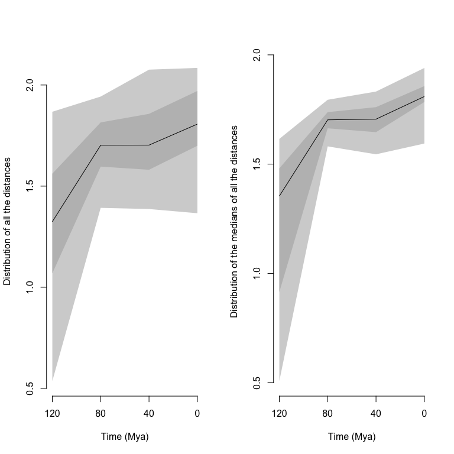

```r
## Graphical parameters
op <- par(bty = "n", mfrow = c(1, 2))

## Plotting both disparity measurements
plot(disparity_centroids, ylab = "Distribution of all the distances")
plot(disparity_centroids_median,
     ylab = "Distribution of the medians of all the distances")
```

```r
par(op)
```

We can then test for differences in the resulting distributions using `test.dispRity` and the `bhatt.coeff` test as described above.

```r
## Probability of overlap in the distribution of medians
test.dispRity(disparity_centroids_median, test = bhatt.coeff)
```

```
##          bhatt.coeff
## 120 : 80  0.15380832
## 120 : 40  0.23690683
## 120 : 0   0.09196152
## 80 : 40   0.92367172
## 80 : 0    0.46576289
## 40 : 0    0.65992821
```

In this case, we are looking at the probability of overlap of the distribution of median distances from centroids among each pair of time slices. In other words, we are measuring whether the medians from each bootstrap pseudo-replicate for each time slice overlap. But of course, we might be interested in the actual distribution of the distances from the centroid rather than simply their central tendencies. This can be problematic depending on the research question asked since we are effectively comparing non-independent medians distributions (because of the pseudo-replication).

One solution, therefore, is to look at the full distribution:

```r
## Probability of overlap for the full distributions
test.dispRity(disparity_centroids, test = bhatt.coeff)
```

```
##          bhatt.coeff
## 120 : 80   0.6401042
## 120 : 40   0.6402923
## 120 : 0    0.5787247
## 80 : 40    0.9423481
## 80 : 0     0.8444910
## 40 : 0     0.9392977
```

These results show the actual overlap among all the measured distances from centroids concatenated across all the bootstraps. For example, when comparing the slices 120 and 80, we are effectively comparing the 5 100 distances (the distances of the five elements in slice 120 bootstrapped 100 times) to the 19 100 distances from slice 80. However, this can also be problematic for some specific tests since the *n* 100 distances are also pseudo-replicates and thus are still not independent.

A second solution is to compare the distributions to each other *for each replicate*:

```r
## Boostrapped probability of overlap for the full distributions
test.dispRity(disparity_centroids, test = bhatt.coeff, concatenate = FALSE)
```

```
##          bhatt.coeff      2.5%       25%       75%     97.5%
## 120 : 80   0.2534144 0.0000000 0.1450953 0.3554093 0.5615906
## 120 : 40   0.2726082 0.0000000 0.1632993 0.3942394 0.6435771
## 120 : 0    0.2172550 0.0000000 0.0000000 0.3464102 0.5913591
## 80 : 40    0.6016956 0.3097953 0.4779726 0.7208207 0.8306227
## 80 : 0     0.4770117 0.1382736 0.3964076 0.5772107 0.7169318
## 40 : 0     0.5327868 0.1724549 0.3887699 0.6761873 0.8781747
```